# **Violent Discipline Against Children: A Global Analysis for Action and Change**

Author

Shantanu Desai

Published

2024-04-26

[output not shown]

#**Introduction** Violent discipline remains a deeply concerning form of child abuse across the globe, affecting millions of children in ways that are both physical and psychological. Despite global efforts to protect children’s rights and improve their well-being, violent forms of punishment continue to be prevalent across regions, cultures, and economies.

This project, using a rich dataset from UNICEF, aims to explore the extent of violent discipline practices worldwide through compelling visual narratives. By analyzing patterns, understanding the socio-economic factors associated with these behaviors, and highlighting countries most in need of intervention, the project seeks to drive awareness and advocate for immediate action. Through powerful visual storytelling, this report brings visibility to a hidden crisis that demands urgent and sustained global attention.

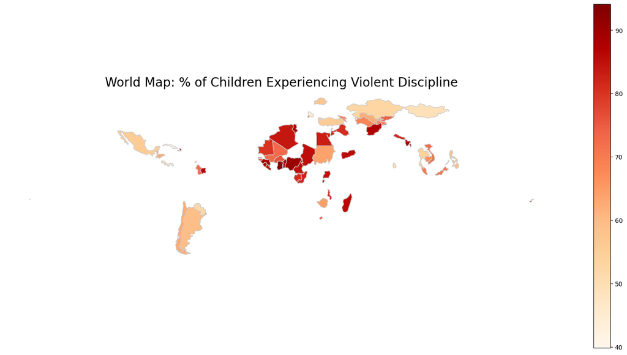

#**Bar Chart** The bar chart starkly highlights countries where violent discipline is most severe. In several nations, more than 80% of children endure violent discipline at home or in their communities. These high rates signal urgent need for focused intervention, legal reforms, and national awareness programs to protect children from culturally normalized violence.

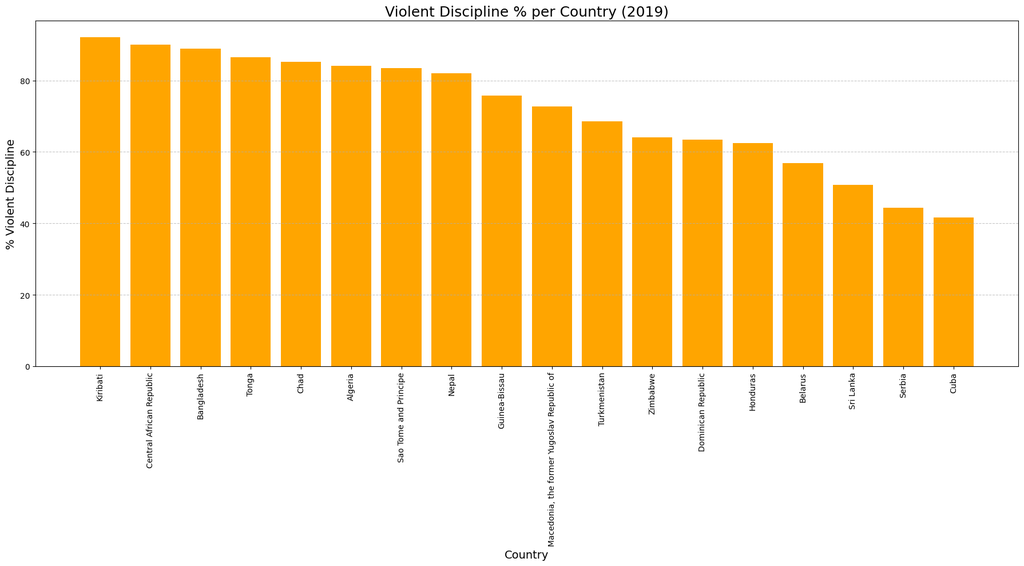

[figure not shown]

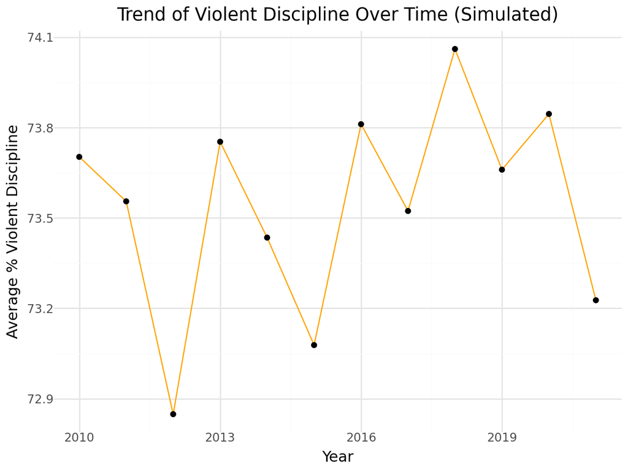

This global overview emphasizes that protecting children requires more than economic growth; it demands societal transformation. It is essential to challenge ingrained beliefs, promote awareness of children’s rights, and provide practical, non-violent alternatives for caregivers. While progress is possible, it requires a deliberate, coordinated effort from international organizations, governments, civil society, and communities themselves.

The story these visuals tell is clear: violent discipline is a preventable harm, and it is the collective responsibility of humanity to eliminate it.

#**Recommendations** Addressing violent discipline globally requires urgent, multi-faceted action. Countries with the highest rates should be prioritized for interventions including legal reforms, parenting support programs, and national education campaigns that promote non-violent methods of child upbringing. Governments must strengthen laws prohibiting corporal punishment in all settings—home, school, and public spaces—and ensure their effective enforcement.

Community-driven initiatives should be expanded to change cultural perceptions about violence, offering families the knowledge and tools they need to discipline children constructively without harm. International bodies must link social protection policies directly with child protection initiatives, recognizing that reducing poverty, improving education access, and empowering parents are all vital strategies in eliminating violence.

Finally, robust data collection systems must be maintained and expanded to monitor progress, adapt strategies, and hold governments accountable. By combining economic, legal, educational, and cultural interventions, the world can move closer to realizing a future where every child grows up free from violence and fear.